# UD 2. Modelos avanzados de NLP. Enfoques con Deep Learning

# Caso práctico 1 - [SOLUCIÓN]

Para esta ejercicio vamos a realizar un Word2Vec personalizado, en esta ocasión no vamos a utilizar ningún modelo pre-entrenado, la idea es realizar un canal de recomendación basado en similaridad, en él, cuando el usuario teclee el nombre de un vehículo, el sistema le proporcionará el vehículo más parecido basándose en similaridad por Wor2Vec, además también se debe incluir una segunda funcionalidad, si el usuario ingresa el nombre de dos vehículos, el sistema debe devolverle cómo de parecidos son de forma porcentual. La fuente original de los datos puede encontrarse en este enlace https://www.kaggle.com/CooperUnion/cardataset también está disponible para su descarga en el siguiente enlace.

Nos encontramos con una dimensionalidad en los datos de 11914 filas x 16 columnas, estas columnas son las siguientes:

- Make: Fabricante del vehículo.
- Model: Modelo del vehículo.
- Year: Año de fabricación
- Engine Fuel Type: Tipo de combustible.
- Engine HP: Caballos de potencia.
- Engine Cylinders: Cilindrada de vehículo.
- Transmission Type: Tipo de transmisión.
- Driven_Wheels: Tracción del vehículo.
- Number of Doors: Número de puertas
- Market Category: Categoría de mercado
- Vehicle Size: Tipo de vehículo por tamaño.
- Vehícle Stlye: Tipo de vehículo por categoría.
- Highway MPG: Consumo de combustible en autopista en millas por galón.
- City mpg: Consumo de combustible en ciudad en millas por galón.
- Popularity: Rating popularidad del vehículo.
- MSRP: Manufacturer’s Suggestted Retail Price: Precio en retail.

1 - Se pide

2 - Solución

## 1 - Se pide

1. Realiza un filtrado de las columnas:
   - Crea una que sea la concatenación del fabricante y modelo del vehículo.
   - Posteriormente quédate con la nueva columna generada y: Tipo de combustible, tipo de transmisión, tracción del vehículo, categoría de mercado, tamaño del vehículo, tipo de vehículo por tamaño y por categoría.
2. Implementa un modelo de Word2Vec (se pueden los parámetros que se consideren)
3. Realiza las siguientes operaciones:
   - Visualiza el vector de Chevrolet Silverado 1500
   - Realiza la comparación de dos vehículos tipo Sedan cualquiera contra un 4dr SUV cualquiera
   - Realiza la comparación de dos vehículos tipo Luxury y Crossover
   - Obtén el modelo más similar a:
     - Acura ZDX
     - BMW 1 Series
     - Porsche 718 Cayman
4. Implementa un modelo PCA y visualiza la matriz de embedding.

## 2 - Solución

Cargamos las librerías

```python
import pandas as pd
import numpy as np
from gensim.models import Word2Vec
from sklearn.decomposition import PCA
import matplotlib.pyplot as plt
```

1. Realiza un filtrado de las columnas:
   - Crea una que sea la concatenación del fabricante y modelo del vehículo.
   - Posteriormente quédate con la nueva columna generada y: Tipo de combustible, tipo de transmisión, tracción del vehículo, categoría de mercado, tamaño del vehículo, tipo de vehículo por tamaño y por categoría.

Observamos la cabecera de los datos y, la dimensionalidad de los mismos

```python
df = pd.read_csv("data.csv")

df.head()
```

|  | Make | Model | Year | Engine Fuel Type | Engine HP | Engine Cylinders | Transmission Type | Driven_Wheels | Number of Doors | Market Category | Vehicle Size | Vehicle Style | highway MPG | city mpg | Popularity | MSRP |
| --- | --- | --- | --- | --- | --- | --- | --- | --- | --- | --- | --- | --- | --- | --- | --- | --- |
| 0 | BMW | 1 Series M | 2011 | premium unleaded (required) | 335.0 | 6.0 | MANUAL | rear wheel drive | 2.0 | Factory Tuner,Luxury,High-Performance | Compact | Coupe | 26 | 19 | 3916 | 46135 |
| 1 | BMW | 1 Series | 2011 | premium unleaded (required) | 300.0 | 6.0 | MANUAL | rear wheel drive | 2.0 | Luxury,Performance | Compact | Convertible | 28 | 19 | 3916 | 40650 |
| 2 | BMW | 1 Series | 2011 | premium unleaded (required) | 300.0 | 6.0 | MANUAL | rear wheel drive | 2.0 | Luxury,High-Performance | Compact | Coupe | 28 | 20 | 3916 | 36350 |
| 3 | BMW | 1 Series | 2011 | premium unleaded (required) | 230.0 | 6.0 | MANUAL | rear wheel drive | 2.0 | Luxury,Performance | Compact | Coupe | 28 | 18 | 3916 | 29450 |
| 4 | BMW | 1 Series | 2011 | premium unleaded (required) | 230.0 | 6.0 | MANUAL | rear wheel drive | 2.0 | Luxury | Compact | Convertible | 28 | 18 | 3916 | 34500 |

```python
df.shape
```

```
(11914, 16)
```

```python
df.info()
```

```
<class 'pandas.core.frame.DataFrame'>
RangeIndex: 11914 entries, 0 to 11913
Data columns (total 16 columns):
 #   Column             Non-Null Count  Dtype
---  ------             --------------  -----
 0   Make               11914 non-null  object
 1   Model              11914 non-null  object
 2   Year               11914 non-null  int64
 3   Engine Fuel Type   11911 non-null  object
 4   Engine HP          11845 non-null  float64
 5   Engine Cylinders   11884 non-null  float64
 6   Transmission Type  11914 non-null  object
 7   Driven_Wheels      11914 non-null  object
 8   Number of Doors    11908 non-null  float64
 9   Market Category    8172 non-null   object
 10  Vehicle Size       11914 non-null  object
 11  Vehicle Style      11914 non-null  object
 12  highway MPG        11914 non-null  int64
 13  city mpg           11914 non-null  int64
 14  Popularity         11914 non-null  int64
 15  MSRP               11914 non-null  int64
dtypes: float64(3), int64(5), object(8)
memory usage: 1.5+ MB
```

```python
df.isna().sum()
```

```
Make                    0
Model                   0
Year                    0
Engine Fuel Type        3
Engine HP              69
Engine Cylinders       30
Transmission Type       0
Driven_Wheels           0
Number of Doors         6
Market Category      3742
Vehicle Size            0
Vehicle Style           0
highway MPG             0
city mpg                0
Popularity              0
MSRP                    0
dtype: int64
```

```python
# Generamos la nueva columna del fabricante y modelo del vehículo
df['Fabricante_Modelo']= df['Make']+ " " + df['Model']

# Seleccionamos solo aquellas columnas que sean válidas para nuestro estudio
df_targets = df[['Fabricante_Modelo', 'Engine Fuel Type',
                 'Transmission Type','Driven_Wheels',
                 'Market Category','Vehicle Size',
                 'Vehicle Style']].copy()

# Juntamos todos los elementos por comas para obtener una lista
all_rows = df_targets.apply(lambda x: ','.join(x.astype(str)), axis=1)

# Ahora separamos cada fila por comas
documents_ = [row.split(',') for row in all_rows]

documents_[:3]
```

```
[['BMW 1 Series M',
  'premium unleaded (required)',
  'MANUAL',
  'rear wheel drive',
  'Factory Tuner',
  'Luxury',
  'High-Performance',
  'Compact',
  'Coupe'],
 ['BMW 1 Series',
  'premium unleaded (required)',
  'MANUAL',
  'rear wheel drive',
  'Luxury',
  'Performance',
  'Compact',
  'Convertible'],
 ['BMW 1 Series',
  'premium unleaded (required)',
  'MANUAL',
  'rear wheel drive',
  'Luxury',
  'High-Performance',
  'Compact',
  'Coupe']]
```

1. Implementa un modelo de Word2Vec (se pueden los parámetros que se consideren)

```python
# Creamos el modelo Wor2Vec
model = Word2Vec(sentences = documents_,  # Conjunto se secuencias
                 size      = 100,        # Dimensión de cada vector
                 window    = 10,         # Tamaño de ventana máximo entre palabras
                 min_count = 2,          # Frecuencia mínima de veces que debe aparecer un término
                 workers   = 4           # Cores de la máquina
                )

model.train(documents_,
            total_examples=len(documents_),
            epochs=100
           )
```

```
(2996796, 8812900)
```

1. Realiza las siguientes operaciones:
   - Visualiza el vector de Chevrolet Silverado 1500
   - Realiza la comparación de dos vehículos tipo Sedan cualquiera contra un 4dr SUV cualquiera
   - Realiza la comparación de dos vehículos tipo Luxury y Crossover
   - Obtén el modelo más similar a:
     - Acura ZDX
     - BMW 1 Series
     - Porsche 718 Cayman

```python
model.wv["Chevrolet Silverado 1500"]
```

```
array([ 0.8306149 ,  0.11325752, -0.66319627,  1.2317902 ,  0.23821466,
        1.0556818 , -1.457611  ,  1.445932  , -0.1783196 ,  1.6356698 ,
        2.350369  ,  1.0928826 , -0.5881526 , -1.1303338 , -2.1913848 ,
        2.3289518 , -0.8983144 ,  0.08646785,  1.5707533 , -3.0142627 ,
       -0.14287487, -1.9934608 , -0.25049227,  2.3853874 , -0.45024267,
       -0.42677566, -1.5749469 , -1.1505051 ,  1.0121181 , -1.3720158 ,
        0.42049757,  1.0807167 ,  0.7367482 , -1.9941399 ,  0.10803239,
       -2.9624422 ,  1.4385324 , -2.5565028 , -1.5263126 , -0.93150467,
        1.0274403 ,  0.6512974 ,  0.13690828, -1.4471538 , -1.1385697 ,
       -0.88879496,  0.26588297,  3.2024457 ,  1.5831227 ,  1.5687484 ,
        0.48228267,  1.0333664 , -1.2302771 , -0.21794404, -1.2468821 ,
       -0.62028474, -1.3393266 , -0.5594211 ,  3.3590581 , -1.4475405 ,
       -0.7774684 , -0.73083436,  0.6002147 , -1.9095597 , -1.9318565 ,
       -1.1068195 , -0.05410369,  2.528108  , -0.37433046,  1.9869725 ,
        1.5726095 ,  0.4253149 , -1.852019  ,  0.17848173, -0.84523106,
        1.4812168 ,  0.7802449 , -0.7453933 ,  0.58215386,  0.8695938 ,
       -1.9850426 ,  1.6195548 ,  0.05794796, -0.25287157,  0.73523885,
       -2.7034168 ,  0.28314915,  0.2356883 , -1.7039129 ,  1.620534  ,
       -0.2006163 ,  0.42616263,  0.28449067, -0.5779346 ,  1.237486  ,
        0.37967464, -0.58112293, -0.36427638, -1.7652669 , -1.8213692 ],
      dtype=float32)
```

```python
df.columns
```

```
Index(['Make', 'Model', 'Year', 'Engine Fuel Type', 'Engine HP',
       'Engine Cylinders', 'Transmission Type', 'Driven_Wheels',
       'Number of Doors', 'Market Category', 'Vehicle Size', 'Vehicle Style',
       'highway MPG', 'city mpg', 'Popularity', 'MSRP', 'Fabricante_Modelo'],
      dtype='object')
```

```python
df["Vehicle Style"].value_counts()
```

```
Sedan                  3048
4dr SUV                2488
Coupe                  1211
Convertible             793
4dr Hatchback           702
Crew Cab Pickup         681
Extended Cab Pickup     623
Wagon                   592
2dr Hatchback           506
Passenger Minivan       417
Regular Cab Pickup      392
2dr SUV                 138
Passenger Van           128
Cargo Van                95
Cargo Minivan            71
Convertible SUV          29
Name: Vehicle Style, dtype: int64
```

```python
df[(df["Vehicle Style"] == "Sedan")]["Fabricante_Modelo"].value_counts()
```

```
Volkswagen Jetta           61
Volkswagen Passat          45
Volkswagen Jetta GLI       44
Cadillac CTS               42
Honda Accord               41
                           ..
Oldsmobile Ciera            1
Volvo S60 Cross Country     1
Lexus GS F                  1
Lincoln MKZ Hybrid          1
Lincoln Zephyr              1
Name: Fabricante_Modelo, Length: 312, dtype: int64
```

```python
df[df["Vehicle Style"] == "4dr SUV"]["Fabricante_Modelo"].value_counts()
```

```
Volvo XC60                54
Honda Pilot               48
Suzuki XL7                39
Kia Sorento               38
Ford Expedition           36
                          ..
Infiniti JX                2
Infiniti FX50              2
Lexus LX 450               2
Mercedes-Benz ML55 AMG     1
GMC Yukon Denali           1
Name: Fabricante_Modelo, Length: 174, dtype: int64
```

```python
model.wv.similarity("GMC Yukon", "Audi 100")
```

```
-0.6177299
```

```python
model.wv.similarity("Toyota Yaris iA", "Toyota 4Runner")
```

```
0.009060695
```

```python
df[df["Market Category"] == "Luxury"]["Fabricante_Modelo"].value_counts()
```

```
Audi A3                    40
Saab 9-3                   29
Mercedes-Benz C-Class      23
Acura TLX                  21
Mercedes-Benz 300-Class    21
                           ..
Volvo Coupe                 1
Hyundai Genesis             1
Lincoln Blackwood           1
Volvo S60 Cross Country     1
Lincoln Zephyr              1
Name: Fabricante_Modelo, Length: 141, dtype: int64
```

```python
df[df["Market Category"] == "Crossover"]["Fabricante_Modelo"].value_counts()
```

```
Honda Pilot                     48
Suzuki XL7                      39
Kia Sorento                     38
GMC Acadia                      32
Honda CR-V                      32
                                ..
Nissan Murano CrossCabriolet     3
Toyota RAV4 EV                   3
Volkswagen Touareg 2             2
Ford Explorer                    2
GMC Acadia Limited               2
Name: Fabricante_Modelo, Length: 64, dtype: int64
```

```python
model.wv.similarity("Audi A3", "Honda Pilot")
```

```
-0.15929542
```

```python
model.wv.similarity("Saab 9-3", "Suzuki XL7")
```

```
0.05913426
```

```python
model.wv.most_similar("Acura ZDX")
```

```
[('BMW 3 Series Gran Turismo', 0.8796995878219604),
 ('BMW 5 Series Gran Turismo', 0.7258099317550659),
 ('Honda Accord Crosstour', 0.6636247634887695),
 ('Cadillac XT5', 0.6040922999382019),
 ('Honda Crosstour', 0.5916486978530884),
 ('Saab 9-4X', 0.5808957815170288),
 ('Infiniti FX45', 0.5554487705230713),
 ('Mercedes-Benz B-Class Electric Drive', 0.5522690415382385),
 ('Subaru B9 Tribeca', 0.5417028665542603),
 ('Lexus IS 250', 0.539528489112854)]
```

```python
model.wv.most_similar("BMW 1 Series")
```

```
[('Porsche Cayman', 0.8916165232658386),
 ('Porsche 718 Cayman', 0.8823450803756714),
 ('Porsche Boxster', 0.8700357675552368),
 ('Subaru BRZ', 0.8212430477142334),
 ('Mazda RX-8', 0.803157389163971),
 ('Chrysler Crossfire', 0.7933868169784546),
 ('BMW Z4 M', 0.7853074669837952),
 ('Scion FR-S', 0.7850476503372192),
 ('BMW M', 0.7792420387268066),
 ('BMW Z3', 0.773759126663208)]
```

```python
model.wv.most_similar("Porsche 718 Cayman")
```

```
[('Porsche Cayman', 0.9742498397827148),
 ('BMW 1 Series', 0.8823450803756714),
 ('BMW Z4 M', 0.8297777771949768),
 ('Porsche Boxster', 0.8161376118659973),
 ('BMW M2', 0.8024457693099976),
 ('Porsche 911', 0.7945148944854736),
 ('BMW M', 0.7891438007354736),
 ('Cadillac CTS-V Coupe', 0.760230541229248),
 ('Audi R8', 0.720707893371582),
 ('Maserati Coupe', 0.7132080793380737)]
```

1. Implementa un modelo PCA y visualiza la matriz de embedding.

```python
# Creamos el modelo PCA vacío para 2 componentes
pca = PCA(n_components=2)

# Obtenemos el PCA sobre los vehículos
pca_cars = pca.fit_transform(model[model.wv.vocab])
```

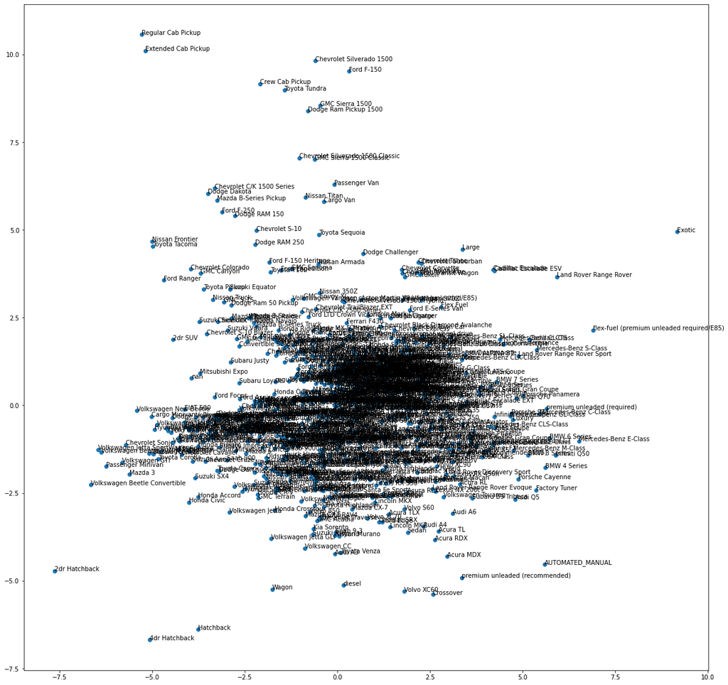

```python
fig, ax = plt.subplots(figsize = (20, 20))

ax.scatter(
    pca_cars[ :, 0], # Primer componente
    pca_cars[ :, 1]  # Segundo componente
)
# Imprimimos cada palabra
for i, palabra in enumerate(list(model.wv.vocab)):
    ax.text(pca_cars[i, 0], pca_cars[i, 1], palabra)

plt.show()
```